# Importing Libraries

```python
import pandas as pd
import requests
import json
import matplotlib.pyplot as plt
import warnings
from IPython.display import display, Image


plt.style.use('seaborn-talk')
warnings.filterwarnings("ignore")
pd.set_option('display.max_colwidth', None)
pd.set_option('mode.chained_assignment', None)
```

# Gathering Data

**Get data from a CSV file provided by Udacity...**

```python
df_archive = pd.read_csv('twitter-archive-enhanced.csv')
print('"df_archive" has', df_archive.shape[0], 'rows, and', df_archive.shape[1], 'columns.')
```

```
"df_archive" has 2356 rows, and 17 columns.
```

**Get data from a TSV file from a URL...**

```python
url = 'https://d17h27t6h515a5.cloudfront.net/topher/2017/August/599fd2ad_image-predictions/image-predictions.tsv'
response = requests.get(url)
with open('image_predictions.tsv', 'wb') as f:
    f.write(response.content)
df_image = pd.read_csv('image_predictions.tsv', sep = '\t')
print('"df_image" has', df_image.shape[0], 'rows, and', df_image.shape[1], 'columns.')
```

```
"df_image" has 2075 rows, and 12 columns.
```

**Get data from Twitter API...**

```python
%%script false

import tweepy
from tweepy import OAuthHandler
import json
from timeit import default_timer as timer
import credentials

# Query Twitter API for each tweet in the Twitter archive and save JSON in a text file
# These are hidden to comply with Twitter's API terms and conditions
consumer_key    = credentials.consumer_key
consumer_secret = credentials.consumer_secret
access_token    = credentials.access_token
access_secret   = credentials.access_secret

auth = OAuthHandler(consumer_key, consumer_secret)
auth.set_access_token(access_token, access_secret)

api = tweepy.API(auth, wait_on_rate_limit=True, wait_on_rate_limit_notify=True)

# NOTE TO STUDENT WITH MOBILE VERIFICATION ISSUES:
# df_1 is a DataFrame with the twitter_archive_enhanced.csv file. You may have to
# change line 17 to match the name of your DataFrame with twitter_archive_enhanced.csv
# NOTE TO REVIEWER: this student had mobile verification issues so the following
# Twitter API code was sent to this student from a Udacity instructor
# Tweet IDs for which to gather additional data via Twitter's API
tweet_ids = df_archive.tweet_id.values
print('Number of tweets =', len(tweet_ids))
print()

# Query Twitter's API for JSON data for each tweet ID in the Twitter archive
count = 0
success = 0
fail = 0
fails_dict = {}
start = timer()

# Save each tweet's returned JSON as a new line in a .txt file
with open('tweet_json.txt', 'w') as outfile:
    # This loop will likely take 20-30 minutes to run because of Twitter's rate limit
    print('Retriving tweets via Twitter API:\n')
    print('{:>5}{:>15}{:>15}{:>20}'.format('Count', 'Success', 'Fail', 'Time (min)'))

    for tweet_id in tweet_ids:
        count += 1
        try:
            tweet = api.get_status(tweet_id, tweet_mode='extended')
            success += 1
#            print(str(count) + ": " + str(tweet_id) + " - Success")
            json.dump(tweet._json, outfile)
            outfile.write('\n')
        except tweepy.TweepError as e:
            fail += 1
#            print(str(count) + ": " + str(tweet_id) + " - Fail")
            fails_dict[tweet_id] = e
            pass
        if count%100 == 0:
            print('{:>5}{:>15}{:>15}{:>20}'.format(count, success, fail, round((timer()-start)/60,2)))

end = timer()

print()
print('Retrieved tweets =', count, '/ Success =', success,
      '/ Fail =', fail, '/ Time =', round((end-start)/60,2), "minutes")
```

```
Couldn't find program: 'false'
```

#### Output of previous cell (was run one time during data collection):

```python
# Number of tweets = 2356

# Retriving tweets via Twitter API:

# Count        Success           Fail          Time (min)
#   100             98              2                0.83
#   200            191              9                1.65
#   300            285             15                2.48
#   400            383             17                 3.3
#   500            483             17                4.14
#   600            581             19                4.96
#   700            681             19                5.79
#   800            779             21                6.62
#   900            874             26                7.45
# Rate limit reached. Sleeping for: 453
#  1000            973             27               15.91
#  1100           1073             27               16.73
#  1200           1173             27               17.54
#  1300           1273             27               18.35
#  1400           1373             27               19.18
#  1500           1473             27                20.0
#  1600           1573             27               20.82
#  1700           1673             27               21.64
#  1800           1772             28               22.47
# Rate limit reached. Sleeping for: 457
#  1900           1872             28                31.0
#  2000           1972             28               31.82
#  2100           2072             28               32.64
#  2200           2172             28               33.46
#  2300           2272             28               34.28

# Retrieved tweets = 2356 / Success = 2328 / Fail = 28 / Time = 34.74 minutes
```

```python
%%script false

print()
print('Failed tweets:')
print()
for fail in fails_dict:
    print('Tweet ID:', fail, '-', fails_dict[fail].args[0][0]['message'])
```

```
Couldn't find program: 'false'
```

#### Output of previous cell (was run one time during data collection):

```python
# Failed tweets:

# Tweet ID: 888202515573088257 - No status found with that ID.
# Tweet ID: 873697596434513921 - No status found with that ID.
# Tweet ID: 872668790621863937 - No status found with that ID.
# Tweet ID: 872261713294495745 - No status found with that ID.
# Tweet ID: 869988702071779329 - No status found with that ID.
# Tweet ID: 866816280283807744 - No status found with that ID.
# Tweet ID: 861769973181624320 - No status found with that ID.
# Tweet ID: 856602993587888130 - No status found with that ID.
# Tweet ID: 856330835276025856 - Sorry, that page does not exist.
# Tweet ID: 851953902622658560 - No status found with that ID.
# Tweet ID: 845459076796616705 - No status found with that ID.
# Tweet ID: 844704788403113984 - No status found with that ID.
# Tweet ID: 842892208864923648 - No status found with that ID.
# Tweet ID: 837366284874571778 - No status found with that ID.
# Tweet ID: 837012587749474308 - No status found with that ID.
# Tweet ID: 829374341691346946 - No status found with that ID.
# Tweet ID: 827228250799742977 - No status found with that ID.
# Tweet ID: 812747805718642688 - No status found with that ID.
# Tweet ID: 802247111496568832 - No status found with that ID.
# Tweet ID: 779123168116150273 - No status found with that ID.
# Tweet ID: 775096608509886464 - No status found with that ID.
# Tweet ID: 771004394259247104 - Sorry, you are not authorized to see this status.
# Tweet ID: 770743923962707968 - No status found with that ID.
# Tweet ID: 766864461642756096 - No status found with that ID.
# Tweet ID: 759923798737051648 - No status found with that ID.
# Tweet ID: 759566828574212096 - No status found with that ID.
# Tweet ID: 754011816964026368 - No status found with that ID.
# Tweet ID: 680055455951884288 - No status found with that ID.
```

```python
df_json = pd.read_json('tweet_json.txt', lines=True)
print('"df_json" has', df_json.shape[0], 'rows, and', df_json.shape[1], 'columns.')
```

```
"df_json" has 2328 rows, and 32 columns.
```

**Let's extract useful data from `df_json`...**

```python
df_tweets = pd.DataFrame(df_json, columns=['id', 'favorite_count', 'retweet_count', 'display_text_range'])
df_tweets[['start', 'tweet_length']] = pd.DataFrame(df_tweets.display_text_range.tolist(), index=df_tweets.index)
del df_tweets['display_text_range']
del df_tweets['start']
df_tweets.rename(columns = {'id':'tweet_id'}, inplace = True)
df_tweets.tweet_length += 1
print('"df_tweets" has', df_tweets.shape[0], 'rows, and', df_tweets.shape[1], 'columns.')
```

```
"df_tweets" has 2328 rows, and 4 columns.
```

# Assessing Data

```python
display(df_archive.sample(3).T)
display(df_archive.describe(percentiles=[]).T.apply(lambda s: s.apply('{0:.2f}'.format)))
display(df_archive.describe(include='O').T)
df_archive.info()
```

|  | 1876 | 1064 | 1859 |
| --- | --- | --- | --- |
| tweet_id | 675111688094527488 | 740995100998766593 | 675497103322386432 |
| in_reply_to_status_id | NaN | NaN | NaN |
| in_reply_to_user_id | NaN | NaN | NaN |
| timestamp | 2015-12-11 00:35:44 +0000 | 2016-06-09 19:52:53 +0000 | 2015-12-12 02:07:14 +0000 |
| source | <a href="http://twitter.com/download/iphone" rel="nofollow">Twitter for iPhone</a> | <a href="http://twitter.com/download/iphone" rel="nofollow">Twitter for iPhone</a> | <a href="http://twitter.com/download/iphone" rel="nofollow">Twitter for iPhone</a> |
| text | Say hello to Oliver. He thought what was inside the pillow should be outside the pillow. Blurry since birth. 8/10 https://t.co/lFU9W31Fg9 | This is Leo. He's a vape god. Blows o's for days. Probably drives a Subaru. Definitely owns multiple fedoras. 10/10 https://t.co/nt2x3fHaRJ | Meet Reggie. He's going for the world record. Must concentrate. Focus up pup. 11/10 we all believe in you Reggie https://t.co/h3AWz4AzuC |
| retweeted_status_id | NaN | NaN | NaN |
| retweeted_status_user_id | NaN | NaN | NaN |
| retweeted_status_timestamp | NaN | NaN | NaN |
| expanded_urls | https://twitter.com/dog_rates/status/675111688094527488/photo/1 | https://twitter.com/dog_rates/status/740995100998766593/photo/1 | https://twitter.com/dog_rates/status/675497103322386432/photo/1 |
| rating_numerator | 8 | 10 | 11 |
| rating_denominator | 10 | 10 | 10 |
| name | Oliver | Leo | Reggie |
| doggo | None | None | None |
| floofer | None | None | None |
| pupper | None | None | None |
| puppo | None | None | None |

|  | count | mean | std | min | 50% | max |
| --- | --- | --- | --- | --- | --- | --- |
| tweet_id | 2356.00 | 742771590321719808.00 | 68567047444761032.00 | 666020888022790144.00 | 719627934716235776.00 | 892420643555336192.00 |
| in_reply_to_status_id | 78.00 | 745507917855750656.00 | 75824920044192880.00 | 665814696700723200.00 | 703870840226598912.00 | 886266357075128320.00 |
| in_reply_to_user_id | 78.00 | 20141706360873208.00 | 125279666255236320.00 | 11856342.00 | 4196983835.00 | 840547864354918400.00 |
| retweeted_status_id | 181.00 | 772039961038007040.00 | 62369278105055600.00 | 666104133288665088.00 | 780465709297995776.00 | 887473957103951872.00 |
| retweeted_status_user_id | 181.00 | 12416983653017580.00 | 95992535331517536.00 | 783214.00 | 4196983835.00 | 787461778435289088.00 |
| rating_numerator | 2356.00 | 13.13 | 45.88 | 0.00 | 11.00 | 1776.00 |
| rating_denominator | 2356.00 | 10.46 | 6.75 | 0.00 | 10.00 | 170.00 |

|  | count | unique | top | freq |
| --- | --- | --- | --- | --- |
| timestamp | 2356 | 2356 | 2016-07-13 23:48:51 +0000 | 1 |
| source | 2356 | 4 | <a href="http://twitter.com/download/iphone" rel="nofollow">Twitter for iPhone</a> | 2221 |
| text | 2356 | 2356 | This is Linus. He just wanted to say hello but no one's paying attention. 12/10 (vid by @rebeccacollinzz) https://t.co/VCijm2eVpR | 1 |
| retweeted_status_timestamp | 181 | 181 | 2016-03-20 23:23:54 +0000 | 1 |
| expanded_urls | 2297 | 2218 | https://twitter.com/dog_rates/status/817827839487737858/video/1 | 2 |
| name | 2356 | 957 | None | 745 |
| doggo | 2356 | 2 | None | 2259 |
| floofer | 2356 | 2 | None | 2346 |
| pupper | 2356 | 2 | None | 2099 |
| puppo | 2356 | 2 | None | 2326 |

```
<class 'pandas.core.frame.DataFrame'>
RangeIndex: 2356 entries, 0 to 2355
Data columns (total 17 columns):
 #   Column                      Non-Null Count  Dtype
---  ------                      --------------  -----
 0   tweet_id                    2356 non-null   int64
 1   in_reply_to_status_id       78 non-null     float64
 2   in_reply_to_user_id         78 non-null     float64
 3   timestamp                   2356 non-null   object
 4   source                      2356 non-null   object
 5   text                        2356 non-null   object
 6   retweeted_status_id         181 non-null    float64
 7   retweeted_status_user_id    181 non-null    float64
 8   retweeted_status_timestamp  181 non-null    object
 9   expanded_urls               2297 non-null   object
 10  rating_numerator            2356 non-null   int64
 11  rating_denominator          2356 non-null   int64
 12  name                        2356 non-null   object
 13  doggo                       2356 non-null   object
 14  floofer                     2356 non-null   object
 15  pupper                      2356 non-null   object
 16  puppo                       2356 non-null   object
dtypes: float64(4), int64(3), object(10)
memory usage: 313.0+ KB
```

## Visual notes

- **Quality:** there are 181 retweets and 78 replies, those raws should be dropped
- **Quality:** `tweet_id` is int, should be string
- **Quality:** `timestamp` is string/object, should be converted to datetime
- **Quality:** `source` is in html, should be stripped to text content
- **Quality:** `rating_numerator` range is unrealistic
- **Quality:** `rating_denominator` values other than 10
- **Tidiness:** `doggo`, `floofer`, `pupper`, and `puppo` stages should be consolidated into one stage column
- **Quality:** the word None should be replaced with NaN/missing value in the last 5 columns
- **Quality:** last step should be to drop unuseful columns

```python
df_archive.tweet_id.duplicated().sum()
```

```
0
```

```python
names = df_archive.name.value_counts()

display(names)
print(dict(filter(lambda elem: elem[0] == elem[0].lower(), names.items())))
```

```
None        745
a            55
Charlie      12
Lucy         11
Cooper       11
           ...
Chef          1
Al            1
Mauve         1
Ashleigh      1
Severus       1
Name: name, Length: 957, dtype: int64
```

```
{'a': 55, 'the': 8, 'an': 7, 'very': 5, 'just': 4, 'one': 4, 'quite': 4, 'not': 2, 'mad': 2, 'getting': 2, 'actually': 2, 'infuriating': 1, 'old': 1, 'my': 1, 'his': 1, 'unacceptable': 1, 'incredibly': 1, 'life': 1, 'light': 1, 'officially': 1, 'by': 1, 'such': 1, 'this': 1, 'space': 1, 'all': 1}
```

```python
df_archive.groupby("rating_denominator")["tweet_id"].count()
```

```
rating_denominator
0         1
2         1
7         1
10     2333
11        3
15        1
16        1
20        2
40        1
50        3
70        1
80        2
90        1
110       1
120       1
130       1
150       1
170       1
Name: tweet_id, dtype: int64
```

## Programmatic notes

- **Quality:** `name` column contains "None" and other lowercase words, should be corrected or changed to NaN
- **Quality:** `rating_numerator` column range from 0 to 1776 while most values are between 1 and 14
- **Quality:** `rating_denominator` column range from 0 to 170 while most values are 10 exactly
- **Quality:** some ratings include decimal points, should by converted to float
- **Quality:** the numerator and denominator should be extracted from text efficiently
- **Quality:** there are some tweets with multiple dogs, should introduce a `ratio` column to simplify
- **Quality:** flawed raws in both rating columns above should be dropped after correction

```python
display(df_image.sample(3).T)
display(df_image.describe(percentiles=[]).T.apply(lambda s: s.apply('{0:.2f}'.format)))
display(df_image.describe(include='O').T)
display(df_image.describe(include='bool').T)
df_image.info()
```

|  | 683 | 1842 | 1375 |
| --- | --- | --- | --- |
| tweet_id | 683849932751646720 | 838476387338051585 | 763103485927849985 |
| jpg_url | https://pbs.twimg.com/media/CX2F4qNUQAAR6Cm.jpg | https://pbs.twimg.com/media/C6Ld0wYWgAQQqMC.jpg | https://pbs.twimg.com/media/CpcWknPXYAAeLP9.jpg |
| img_num | 1 | 3 | 2 |
| p1 | hog | Great_Pyrenees | seat_belt |
| p1_conf | 0.458855 | 0.997692 | 0.685821 |
| p1_dog | False | True | False |
| p2 | Mexican_hairless | kuvasz | ice_bear |
| p2_conf | 0.164906 | 0.00100064 | 0.0815972 |
| p2_dog | True | True | False |
| p3 | wild_boar | Newfoundland | chow |
| p3_conf | 0.1117 | 0.000404556 | 0.0390848 |
| p3_dog | False | True | True |

|  | count | mean | std | min | 50% | max |
| --- | --- | --- | --- | --- | --- | --- |
| tweet_id | 2075.00 | 738451357852539008.00 | 67852033330235656.00 | 666020888022790144.00 | 711998809858043904.00 | 892420643555336192.00 |
| img_num | 2075.00 | 1.20 | 0.56 | 1.00 | 1.00 | 4.00 |
| p1_conf | 2075.00 | 0.59 | 0.27 | 0.04 | 0.59 | 1.00 |
| p2_conf | 2075.00 | 0.13 | 0.10 | 0.00 | 0.12 | 0.49 |
| p3_conf | 2075.00 | 0.06 | 0.05 | 0.00 | 0.05 | 0.27 |

|  | count | unique | top | freq |
| --- | --- | --- | --- | --- |
| jpg_url | 2075 | 2009 | https://pbs.twimg.com/media/DA7iHL5U0AA1OQo.jpg | 2 |
| p1 | 2075 | 378 | golden_retriever | 150 |
| p2 | 2075 | 405 | Labrador_retriever | 104 |
| p3 | 2075 | 408 | Labrador_retriever | 79 |

|  | count | unique | top | freq |
| --- | --- | --- | --- | --- |
| p1_dog | 2075 | 2 | True | 1532 |
| p2_dog | 2075 | 2 | True | 1553 |
| p3_dog | 2075 | 2 | True | 1499 |

```
<class 'pandas.core.frame.DataFrame'>
RangeIndex: 2075 entries, 0 to 2074
Data columns (total 12 columns):
 #   Column    Non-Null Count  Dtype
---  ------    --------------  -----
 0   tweet_id  2075 non-null   int64
 1   jpg_url   2075 non-null   object
 2   img_num   2075 non-null   int64
 3   p1        2075 non-null   object
 4   p1_conf   2075 non-null   float64
 5   p1_dog    2075 non-null   bool
 6   p2        2075 non-null   object
 7   p2_conf   2075 non-null   float64
 8   p2_dog    2075 non-null   bool
 9   p3        2075 non-null   object
 10  p3_conf   2075 non-null   float64
 11  p3_dog    2075 non-null   bool
dtypes: bool(3), float64(3), int64(2), object(4)
memory usage: 152.1+ KB
```

## Visual notes

- **Quality:** `tweet_id` is int, should be string
- **Quality:** breed predictions should be combined in one column prioritizing from 1 to 3
- **Quality:** rows with tweets that are not dogs in all prediction columns should be dropped
- **Quality:** breeds include mixed case and underscores, should be corrected to title case
- **Quality:** at the end unnecessary columns should be dropped

```python
df_image.tweet_id.duplicated().sum()
```

```
0
```

```python
df_image.jpg_url.duplicated().sum()
```

```
66
```

## Programmatic notes

- **Quality:** `jpg_url` column includes duplicates, rows should be dropped keeping first occurrence

```python
display(df_tweets.sample(3).T)
display(df_tweets.describe(percentiles=[], include='all').T)
df_tweets.info()
```

|  | 1254 | 945 | 1533 |
| --- | --- | --- | --- |
| tweet_id | 708810915978854401 | 750086836815486976 | 688519176466644993 |
| favorite_count | 15679 | 2087 | 2215 |
| retweet_count | 6493 | 508 | 687 |
| tweet_length | 112 | 106 | 98 |

|  | count | mean | std | min | 50% | max |
| --- | --- | --- | --- | --- | --- | --- |
| tweet_id | 2328.0 | 7.418403e+17 | 6.823143e+16 | 6.660209e+17 | 7.180382e+17 | 8.924206e+17 |
| favorite_count | 2328.0 | 7.245478e+03 | 1.125365e+04 | 0.000000e+00 | 3.138500e+03 | 1.488820e+05 |
| retweet_count | 2328.0 | 2.552470e+03 | 4.322170e+03 | 1.000000e+00 | 1.187000e+03 | 7.320900e+04 |
| tweet_length | 2328.0 | 1.120644e+02 | 2.739478e+01 | 1.200000e+01 | 1.170000e+02 | 1.660000e+02 |

```
<class 'pandas.core.frame.DataFrame'>
RangeIndex: 2328 entries, 0 to 2327
Data columns (total 4 columns):
 #   Column          Non-Null Count  Dtype
---  ------          --------------  -----
 0   tweet_id        2328 non-null   int64
 1   favorite_count  2328 non-null   int64
 2   retweet_count   2328 non-null   int64
 3   tweet_length    2328 non-null   int64
dtypes: int64(4)
memory usage: 72.9 KB
```

## Visual notes

- **Quality:** `tweet_id` is int, should be string

## Overall note on all dataframes

- **Tidiness:** join `df_archive`, `df_image`, and `df_tweets` as dataframes should be combined into one `df_final` dataframe
- **Tidiness:** drop all columns that are no longer needed

# Cleaning Data

**We first start by creating copies of the three main data frames**

```python
df_archive_clean = df_archive.copy()
df_image_clean = df_image.copy()
df_tweets_clean = df_tweets.copy()
```

**We will follow the define, code, and test methodology on the clean copies from now on:**

*Quality issue (1):*

Define: There are 181 retweets and 78 replies, those rows should be dropped

Code:

```python
print('Number of replies in dataset =', df_archive_clean.in_reply_to_status_id.count())
print('Number of retweets in dataset =', df_archive_clean.retweeted_status_id.count())
```

```
Number of replies in dataset = 78
Number of retweets in dataset = 181
```

```python
df_archive_clean.drop(df_archive[(~df_archive_clean.in_reply_to_status_id.isna())
                                |(~df_archive_clean.retweeted_status_id.isna())].index,
                                inplace=True)
```

Test:

```python
print('Number of replies in dataset =', df_archive_clean.in_reply_to_status_id.count())
print('Number of retweets in dataset =', df_archive_clean.retweeted_status_id.count())
```

```
Number of replies in dataset = 0
Number of retweets in dataset = 0
```

*Quality issue (2):*

Define: `tweet_id` is int, should be string for all three dataframes

Code:

```python
df_archive_clean['tweet_id'] = df_archive_clean['tweet_id'].astype('str')
df_image_clean['tweet_id'] = df_image_clean['tweet_id'].astype('str')
df_tweets_clean['tweet_id'] = df_tweets_clean['tweet_id'].astype('str')
```

Test:

```python
display(df_archive_clean['tweet_id'].dtype)
display(df_image_clean['tweet_id'].dtype)
display(df_tweets_clean['tweet_id'].dtype)
```

```
dtype('O')
```

```
dtype('O')
```

```
dtype('O')
```

*Tidiness issue (1):*

Define: join `df_archive`, `df_image`, and `df_tweets` as dataframes should be combined into one `df_final` dataframe

Code:

```python
df_final = pd.merge(pd.merge(df_tweets_clean, df_image_clean, on='tweet_id'), df_archive_clean, on='tweet_id')
```

Test:

```python
df_final.info()
```

```
<class 'pandas.core.frame.DataFrame'>
Int64Index: 1963 entries, 0 to 1962
Data columns (total 31 columns):
 #   Column                      Non-Null Count  Dtype
---  ------                      --------------  -----
 0   tweet_id                    1963 non-null   object
 1   favorite_count              1963 non-null   int64
 2   retweet_count               1963 non-null   int64
 3   tweet_length                1963 non-null   int64
 4   jpg_url                     1963 non-null   object
 5   img_num                     1963 non-null   int64
 6   p1                          1963 non-null   object
 7   p1_conf                     1963 non-null   float64
 8   p1_dog                      1963 non-null   bool
 9   p2                          1963 non-null   object
```

[output cut: 23 more lines]

**Note: We will only use `df_final` from now on.**

*Quality issue (3):*

Define: breed predictions should be combined in one column prioritizing from 1 to 3, then rows with tweets that are not dogs in all prediction columns should be dropped

Code:

```python
breed = []

def dog_breed(df):
    if   df['p1_dog']: breed.append(df['p1'])
    elif df['p2_dog']: breed.append(df['p2'])
    elif df['p3_dog']: breed.append(df['p3'])
    else: breed.append(pd.np.nan)

df_final.apply(dog_breed, axis=1)
df_final['breed'] = breed

# let's make it look better by replacing '_' with space and making it title case
df_final['breed'] = df_final['breed'].str.replace('_',' ').str.title()
```

```python
print('Number of valid breed values =', df_final.breed.value_counts().sum())
print('Number of null breed values =', df_final.breed.isna().sum())

df_final.drop(df_final[df_final.breed.isna()].index, inplace=True)
```

```
Number of valid breed values = 1658
Number of null breed values = 305
```

Test:

```python
print('Number of valid breed values =', df_final.breed.value_counts().sum())
print('Number of null breed values =', df_final.breed.isna().sum())
```

```
Number of valid breed values = 1658
Number of null breed values = 0
```

*Quality issue (4):*

Define: `timestamp` is string/object, should be converted to datetime

Code:

```python
df_final['timestamp'] = pd.to_datetime(df_final['timestamp'])
```

Test:

```python
df_final['timestamp'].dtype
```

```
datetime64[ns, UTC]
```

*Quality issue (5):*

Define: `source` is in html, should be stripped to text content

Code:

```python
display(df_final.source.value_counts())
df_final.source = df_final.source.apply(lambda s: s.split('>')[1].split('<')[0])
```

```
<a href="http://twitter.com/download/iphone" rel="nofollow">Twitter for iPhone</a>     1628
<a href="http://twitter.com" rel="nofollow">Twitter Web Client</a>                       22
<a href="https://about.twitter.com/products/tweetdeck" rel="nofollow">TweetDeck</a>       8
Name: source, dtype: int64
```

Test:

```python
df_final.source.value_counts()
```

```
Twitter for iPhone    1628
Twitter Web Client      22
TweetDeck                8
Name: source, dtype: int64
```

*Quality issue (6):*

Define: `rating_denominator` column is problematic, some values other than 10, we will investigate further below

Code:

```python
print(df_final.query('rating_denominator!=10').tweet_id.count())
```

```
16
```

Let's try to extract more accurate denominators and make the column float type

```python
df_final.rating_denominator = df_final.rating_denominator.astype(float)
df_final['denominator'] = df_final.text.str.extract(
    '(\d+(?:\.\d+)?)/(\d+(?:\.\d+)?)(?!.*\d+(?:\.\d+)?/\d+(?:\.\d+)?)')[1].astype(float)
```

Test:

```python
print(df_final.query('denominator!=10').tweet_id.count())
```

```
11
```

Reduced by 5, let's dig more!

*Quality issue (7):*

Define: `rating_numerator` column is problematic, some odd values, we will investigate further below

Code:

```python
print(df_final.rating_numerator.value_counts()[:15].sum())
print(df_final.rating_numerator.value_counts()[:15])
```

```
1643
12     419
10     356
11     352
13     217
9      132
8       68
7       32
14      21
6       16
5       14
4        7
3        5
2        2
144      1
1        1
Name: rating_numerator, dtype: int64
```

Most values are between 1 and 14 in the top 15 values, lets extract the correct numerator.

```python
df_final.rating_numerator = df_final.rating_numerator.astype(float)
df_final['numerator'] = df_final.text.str.extract(
    '(\d+(?:\.\d+)?)/(\d+(?:\.\d+)?)(?!.*\d+(?:\.\d+)?/\d+(?:\.\d+)?)')[0].astype(float)
```

Test:

```python
df_final['test'] = pd.np.where(
    (df_final['rating_numerator'] == df_final['numerator']) &
    (df_final['rating_denominator'] == df_final['denominator']), True, False)

display(df_final['test'].value_counts())
display(df_final.loc[df_final['test'] == False,
        ['text', 'rating_numerator', 'rating_denominator', 'numerator', 'denominator']])
```

```
True     1630
False      28
Name: test, dtype: int64
```

|  | text | rating_numerator | rating_denominator | numerator | denominator |
| --- | --- | --- | --- | --- | --- |
| 39 | This is Bella. She hopes her smile made you smile. If not, she is also offering you her favorite monkey. 13.5/10 https://t.co/qjrljjt948 | 5.0 | 10.0 | 13.50 | 10.0 |
| 495 | This is Logan, the Chow who lived. He solemnly swears he's up to lots of good. H*ckin magical af 9.75/10 https://t.co/yBO5wuqaPS | 75.0 | 10.0 | 9.75 | 10.0 |
| 544 | This is Sophie. She's a Jubilant Bush Pupper. Super h*ckin rare. Appears at random just to smile at the locals. 11.27/10 would smile back https://t.co/QFaUiIHxHq | 27.0 | 10.0 | 11.27 | 10.0 |
| 546 | "Yep... just as I suspected. You're not flossing." 12/10 and 11/10 for the pup not flossing https://t.co/SuXcI9B7pQ | 12.0 | 10.0 | 11.00 | 10.0 |
| 738 | This is Bookstore and Seaweed. Bookstore is tired and Seaweed is an asshole. 10/10 and 7/10 respectively https://t.co/eUGjGjjFVJ | 10.0 | 10.0 | 7.00 | 10.0 |
| 787 | After so many requests, this is Bretagne. She was the last surviving 9/11 search dog, and our second ever 14/10. RIP https://t.co/XAVDNDaVgQ | 9.0 | 11.0 | 14.00 | 10.0 |
| 877 | Happy 4/20 from the squad! 13/10 for all https://t.co/eV1diwds8a | 4.0 | 20.0 | 13.00 | 10.0 |
| 911 | This is Bluebert. He just saw that both #FinalFur match ups are split 50/50. Amazed af. 11/10 https://t.co/Kky1DPG4iq | 50.0 | 50.0 | 11.00 | 10.0 |
| 927 | Meet Travis and Flurp. Travis is pretty chill but Flurp can't lie down properly. 10/10 &amp; 8/10\nget it together Flurp https://t.co/Akzl5ynMmE | 10.0 | 10.0 | 8.00 | 10.0 |
| 1045 | This is Socks. That water pup w the super legs just splashed him. Socks did not appreciate that. 9/10 and 2/10 https://t.co/8rc5I22bBf | 9.0 | 10.0 | 2.00 | 10.0 |
| 1138 | Meet Oliviér. He takes killer selfies. Has a dog of his own. It leaps at random &amp; can't bark for shit. 10/10 &amp; 5/10 https://t.co/6NgsQJuSBJ | 10.0 | 10.0 | 5.00 | 10.0 |
| 1172 | When bae says they can't go out but you see them with someone else that same night. 5/10 &amp; 10/10 for heartbroken pup https://t.co/aenk0KpoWM | 5.0 | 10.0 | 10.00 | 10.0 |
| 1198 | Meet Fynn &amp; Taco. Fynn is an all-powerful leaf lord and Taco is in the wrong place at the wrong time. 11/10 &amp; 10/10 https://t.co/MuqHPvtL8c | 11.0 | 10.0 | 10.00 | 10.0 |
| 1306 | This is Darrel. He just robbed a 7/11 and is in a high speed police chase. Was just spotted by the helicopter 10/10 https://t.co/7EsP8LmSp5 | 7.0 | 11.0 | 10.00 | 10.0 |
| 1352 | Here we have uncovered an entire battalion of holiday puppers. Average of 11.26/10 https://t.co/eNm2S6p9BD | 26.0 | 10.0 | 11.26 | 10.0 |
| 1427 | Meet Tassy &amp; Bee. Tassy is pretty chill, but Bee is convinced the Ruffles are haunted. 10/10 &amp; 11/10 respectively https://t.co/fgORpmTN9C | 10.0 | 10.0 | 11.00 | 10.0 |
| 1461 | These two pups just met and have instantly bonded. Spectacular scene. Mesmerizing af. 10/10 and 7/10 for blue dog https://t.co/gwryaJO4tC | 10.0 | 10.0 | 7.00 | 10.0 |
| 1517 | Meet Rufio. He is unaware of the pink legless pupper wrapped around him. Might want to get that checked 10/10 &amp; 4/10 https://t.co/KNfLnYPmYh | 10.0 | 10.0 | 4.00 | 10.0 |
| 1521 | Two gorgeous dogs here. Little waddling dog is a rebel. Refuses to look at camera. Must be a preteen. 5/10 &amp; 8/10 https://t.co/YPfw7oahbD | 5.0 | 10.0 | 8.00 | 10.0 |
| 1586 | Meet Eve. She's a raging alcoholic 8/10 (would b 11/10 but pupper alcoholism is a tragic issue that I can't condone) https://t.co/U36HYQIijg | 8.0 | 10.0 | 11.00 | 10.0 |
| 1626 | 10/10 for dog. 7/10 for cat. 12/10 for human. Much skill. Would pet all https://t.co/uhx5gfpx5k | 10.0 | 10.0 | 12.00 | 10.0 |
| 1678 | Meet Holly. She's trying to teach small human-like pup about blocks but he's not paying attention smh. 11/10 &amp; 8/10 https://t.co/RcksaUrGNu | 11.0 | 10.0 | 8.00 | 10.0 |
| 1727 | Meet Hank and Sully. Hank is very proud of the pumpkin they found and Sully doesn't give a shit. 11/10 and 8/10 https://t.co/cwoP1ftbrj | 11.0 | 10.0 | 8.00 | 10.0 |
| 1789 | Here we have Pancho and Peaches. Pancho is a Condoleezza Gryffindor, and Peaches is just an asshole. 10/10 &amp; 7/10 https://t.co/Lh1BsJrWPp | 10.0 | 10.0 | 7.00 | 10.0 |
| 1826 | This is Spark. He's nervous. Other dog hasn't moved in a while. Won't come when called. Doesn't fetch well 8/10&amp;1/10 https://t.co/stEodX9Aba | 8.0 | 10.0 | 1.00 | 10.0 |
| 1871 | This is Kial. Kial is either wearing a cape, which would be rad, or flashing us, which would be rude. 10/10 or 4/10 https://t.co/8zcwIoiuqR | 10.0 | 10.0 | 4.00 | 10.0 |
| 1880 | Two dogs in this one. Both are rare Jujitsu Pythagoreans. One slightly whiter than other. Long legs. 7/10 and 8/10 https://t.co/ITxxcc4v9y | 7.0 | 10.0 | 8.00 | 10.0 |
| 1942 | This is an Albanian 3 1/2 legged Episcopalian. Loves well-polished hardwood flooring. Penis on the collar. 9/10 https://t.co/d9NcXFKwLv | 1.0 | 2.0 | 9.00 | 10.0 |

After I took the time to inspect all the above tweets on Twitter, I discovered that:

Indexes: 546,738,927,1172,1198,1427,1727,1789 are about two dogs, so we will take average

Indexes: 1045,1138,1461,1517,1626,1678,1826,1871,1880 are wrong, so we will revert to original

I will solve the last two sets of indexes manually in the next quality issue.

*Quality issue (8):*

Define: correct numerator manually based on last investigation

Code:

```python
# Indexes: 546,738,927,1172,1198,1427,1727,1789 are about two dogs, so we will take average
idx_list1 = [546,738,927,1172,1198,1427,1727,1789]
df_final.numerator[idx_list1] = (df_final.numerator[idx_list1] + df_final.rating_numerator[idx_list1]) / 2

# Indexes: 1045,1138,1461,1517,1626,1678,1826,1871,1880 are wrong, so we will revert to original
idx_list2 = [1045,1138,1461,1517,1626,1678,1826,1871,1880]
df_final.numerator[idx_list2] = df_final.rating_numerator[idx_list2]
```

Test:

```python
display(df_final.numerator[idx_list1])
display(df_final.numerator[idx_list2])
```

```
546     11.5
738      8.5
927      9.0
1172     7.5
1198    10.5
1427    10.5
1727     9.5
1789     8.5
Name: numerator, dtype: float64
```

```
1045     9.0
1138    10.0
1461    10.0
1517    10.0
1626    10.0
1678    11.0
1826     8.0
1871    10.0
1880     7.0
Name: numerator, dtype: float64
```

*Quality issue (9):*

Define: Now, how about denominators other than 10 and numerator equal to 0? Let's investigate

Code:

```python
df_final.query('denominator != 10')[['text','denominator']]
```

|  | text | denominator |
| --- | --- | --- |
| 316 | The floofs have been released I repeat the floofs have been released. 84/70 https://t.co/NIYC820tmd | 70.0 |
| 378 | Meet Sam. She smiles 24/7 &amp; secretly aspires to be a reindeer. \nKeep Sam smiling by clicking and sharing this link:\nhttps://t.co/98tB8y7y7t https://t.co/LouL5vdvxx | 7.0 |
| 652 | Why does this never happen at my front door... 165/150 https://t.co/HmwrdfEfUE | 150.0 |
| 932 | Happy Saturday here's 9 puppers on a bench. 99/90 good work everybody https://t.co/mpvaVxKmc1 | 90.0 |
| 956 | Here's a brigade of puppers. All look very prepared for whatever happens next. 80/80 https://t.co/0eb7R1Om12 | 80.0 |
| 974 | From left to right:\nCletus, Jerome, Alejandro, Burp, &amp; Titson\nNone know where camera is. 45/50 would hug all at once https://t.co/sedre1ivTK | 50.0 |
| 1038 | Here is a whole flock of puppers. 60/50 I'll take the lot https://t.co/9dpcw6MdWa | 50.0 |
| 1113 | Happy Wednesday here's a bucket of pups. 44/40 would pet all at once https://t.co/HppvrYuamZ | 40.0 |
| 1281 | Someone help the girl is being mugged. Several are distracting her while two steal her shoes. Clever puppers 121/110 https://t.co/1zfnTJLt55 | 110.0 |
| 1412 | IT'S PUPPERGEDDON. Total of 144/120 ...I think https://t.co/ZanVtAtvIq | 120.0 |
| 1470 | Here we have an entire platoon of puppers. Total score: 88/80 would pet all at once https://t.co/y93p6FLvVw | 80.0 |

```python
df_final.query('numerator == 0')[['text','numerator']]
```

|  | text | numerator |
| --- | --- | --- |
| 229 | When you're so blinded by your systematic plagiarism that you forget what day it is. 0/10 https://t.co/YbEJPkg4Ag | 0.0 |

Index: 378 has no rating, row to be dropped

Index: 229 is not a about a dog, row to be dropped

Indexes: 316,652,932,956,974,1038,1113,1281,1412,1470 are multiple dogs, we will fix and then introduce `ratio`

```python
# Index: 378 has no rating, row to be dropped
# Index: 229 is not a about a dog, row to be dropped

df_final = df_final.drop(229)
df_final = df_final.drop(378)

# Indexes: 316,652,932,956,974,1038,1113,1281,1412,1470 are multiple dogs we'll take average
idx_list3 = [316,652,932,956,974,1038,1113,1281,1412,1470]
df_final.numerator[idx_list3] = round(df_final.numerator[idx_list3] / df_final.denominator[idx_list3] * 10, 1)
df_final.denominator[idx_list3] = 10.0
```

Let's introduce `ratio` of numerator and denominator

```python
df_final['ratio'] = round(df_final.numerator / df_final.denominator, 1)
```

Test:

```python
df_final[((df_final['numerator'] > 14) & (df_final['denominator'] <= 10))]
```

|  | tweet_id | favorite_count | retweet_count | tweet_length | jpg_url | img_num | p1 | p1_conf | p1_dog | p2 | ... | name | doggo | floofer | pupper | puppo | breed | denominator | numerator | test | ratio |
| --- | --- | --- | --- | --- | --- | --- | --- | --- | --- | --- | --- | --- | --- | --- | --- | --- | --- | --- | --- | --- | --- |

0 rows × 36 columns

```python
df_final.query('denominator != 10')[['denominator']].count()
```

```
denominator    0
dtype: int64
```

```python
df_final.query('numerator == 0')[['text','numerator']]
```

|  | text | numerator |
| --- | --- | --- |

```python
df_final.ratio.value_counts()
```

```
1.2    422
1.1    359
1.0    358
1.3    218
0.9    134
0.8     71
0.7     31
1.4     23
0.6     16
0.5     11
0.4      6
0.3      5
0.2      2
Name: ratio, dtype: int64
```

*Tidiness issue (2):*

Define: `doggo`, `floofer`, `pupper`, and `puppo` stages should be consolidated into one `stage` column

Code:

```python
display(df_final.groupby(['doggo', 'floofer', 'pupper', 'puppo']).size().reset_index().rename(columns={0: 'total'}))
df_final.doggo.replace('None', '', inplace=True)
df_final.floofer.replace('None', '', inplace=True)
df_final.pupper.replace('None', '', inplace=True)
df_final.puppo.replace('None', '', inplace=True)
display(df_final.groupby(['doggo', 'floofer', 'pupper', 'puppo']).size().reset_index().rename(columns={0: 'total'}))
```

|  | doggo | floofer | pupper | puppo | total |
| --- | --- | --- | --- | --- | --- |
| 0 | None | None | None | None | 1400 |
| 1 | None | None | None | puppo | 21 |
| 2 | None | None | pupper | None | 166 |
| 3 | None | floofer | None | None | 7 |
| 4 | doggo | None | None | None | 53 |
| 5 | doggo | None | None | puppo | 1 |
| 6 | doggo | None | pupper | None | 7 |
| 7 | doggo | floofer | None | None | 1 |

|  | doggo | floofer | pupper | puppo | total |
| --- | --- | --- | --- | --- | --- |
| 0 |  |  |  |  | 1400 |
| 1 |  |  |  | puppo | 21 |
| 2 |  |  | pupper |  | 166 |
| 3 |  | floofer |  |  | 7 |
| 4 | doggo |  |  |  | 53 |
| 5 | doggo |  |  | puppo | 1 |
| 6 | doggo |  | pupper |  | 7 |
| 7 | doggo | floofer |  |  | 1 |

```python
df_final['stage'] = df_final['doggo'] + df_final['floofer'] + df_final['pupper'] + df_final['puppo']
```

```python
df_final.stage.value_counts()
```

```
                1400
pupper           166
doggo             53
puppo             21
doggopupper        7
floofer            7
doggofloofer       1
doggopuppo         1
Name: stage, dtype: int64
```

```python
df_final.stage = df_final.stage.str.replace('doggofloofer','multiple')
df_final.stage = df_final.stage.str.replace('doggopupper','multiple')
df_final.stage = df_final.stage.str.replace('doggopuppo','multiple')
df_final.loc[df_final.stage.eq(''), 'stage'] = pd.np.nan
```

Test:

```python
df_final.stage.value_counts()
```

```
pupper      166
doggo        53
puppo        21
multiple      9
floofer       7
Name: stage, dtype: int64
```

*Quality issue (10):*

Define: `name` column contains "None" and other lowercase words, should be corrected or changed to NaN

Code:

```python
print(dict(filter(lambda x: x[0] == x[0].lower(), df_final.name.value_counts().items())))
```

```
{'a': 46, 'the': 7, 'an': 4, 'just': 3, 'one': 3, 'very': 3, 'quite': 2, 'getting': 2, 'infuriating': 1, 'all': 1, 'light': 1, 'my': 1, 'unacceptable': 1, 'not': 1, 'incredibly': 1, 'actually': 1, 'space': 1, 'officially': 1}
```

Let's see if there are actual names in the first item above

```python
test_names = dict(df_final.text[df_final.text.str.startswith('This is a')].str.find('named'))
for k,v in test_names.items():
  if v > 0: print(k, end=',')
```

```
1478,1571,1650,1680,1730,1742,1774,1802,1815,1828,1845,1859,1865,1872,1881,1918,1921,
```

```python
print(df_final.text[1478])
print(df_final.text[1680])
print(df_final.text[1802])
```

```
This is a Sizzlin Menorah spaniel from Brooklyn named Wylie. Lovable eyes. Chiller as hell. 10/10 and I'm out.. poof https://t.co/7E0AiJXPmI
This is a Helvetica Listerine named Rufus. This time Rufus will be ready for the UPS guy. He'll never expect it 9/10 https://t.co/34OhVhMkVr
This is a Slovakian Helter Skelter Feta named Leroi. Likes to skip on roofs. Good traction. Much balance. 10/10 wow! https://t.co/Dmy2mY2Qj5
```

Indeed, there are names not extracted by the original dataset... Let's try to extract some...

```python
df_temp = df_final[df_final.name.str.startswith('a')].text.str.extract(r'(?<=named )(\w+)').dropna(). \
   append(df_final[df_final.name.str.startswith('a')].text.str.extract(r'(?<=name is )(\w+)').dropna(). \
   append(df_final[df_final.name.str.startswith('None')].text.str.extract(r'(?<=named )(\w+)').dropna(). \
   append(df_final[df_final.name.str.startswith('None')].text.str.extract(r'(?<=name is )(\w+)').dropna())))

print('Found', len(df_temp), 'names.')
print()
print(list(df_temp[0]))
```

```
Found 24 names.

['Wylie', 'Kip', 'Jacob', 'Rufus', 'Spork', 'Hemry', 'Alfredo', 'Leroi', 'Berta', 'Chuk', 'Alfonso', 'Cheryl', 'Jessiga', 'Klint', 'Kohl', 'Octaviath', 'Johm', 'Daryl', 'Zeus', 'Guss', 'Tickles', 'Zoey', 'Sabertooth', 'Big']
```

Let's put these names into the main dataframe...

```python
names = dict(df_temp)[0]
#print(names.items())
for idx, name in names.items():
    df_final.name[idx] = names[idx]
```

Test:

```python
display(df_final.loc[[1478, 1680, 1802], ['text','name']])
print()

df_temp = df_final[df_final.name.str.startswith('a')].text.str.extract(r'(?<=named )(\w+)').dropna(). \
   append(df_final[df_final.name.str.startswith('a')].text.str.extract(r'(?<=name is )(\w+)').dropna(). \
   append(df_final[df_final.name.str.startswith('None')].text.str.extract(r'(?<=named )(\w+)').dropna(). \
   append(df_final[df_final.name.str.startswith('None')].text.str.extract(r'(?<=name is )(\w+)').dropna())))
print(len(df_temp), 'dog names to extract.')
```

|  | text | name |
| --- | --- | --- |
| 1478 | This is a Sizzlin Menorah spaniel from Brooklyn named Wylie. Lovable eyes. Chiller as hell. 10/10 and I'm out.. poof https://t.co/7E0AiJXPmI | Wylie |
| 1680 | This is a Helvetica Listerine named Rufus. This time Rufus will be ready for the UPS guy. He'll never expect it 9/10 https://t.co/34OhVhMkVr | Rufus |
| 1802 | This is a Slovakian Helter Skelter Feta named Leroi. Likes to skip on roofs. Good traction. Much balance. 10/10 wow! https://t.co/Dmy2mY2Qj5 | Leroi |

```
0 dog names to extract.
```

*Quality issue (11):*

Define: replace None and lowercase words in `name` to NaN

Code:

```python
names_drop = list(filter(lambda x: x[0] == x[0].lower(), df_final.name.value_counts().keys()))
names_drop.append('None')
print(names_drop)
```

```
['a', 'the', 'one', 'an', 'very', 'just', 'quite', 'getting', 'infuriating', 'all', 'my', 'light', 'unacceptable', 'not', 'actually', 'incredibly', 'space', 'officially', 'None']
```

```python
df_final['name'].isnull().sum()
```

```
0
```

```python
for item in names_drop:
    namemask = df_final.name.eq(item)
    df_final.loc[namemask, 'name'] = pd.np.nan
```

Test:

```python
names_drop = list(filter(lambda x: x[0] == x[0].lower(), df_final.name.value_counts().keys()))
print(names_drop)
```

```
[]
```

```python
display(df_final.loc[[1478, 1680, 1802], ['text','name']])
```

|  | text | name |
| --- | --- | --- |
| 1478 | This is a Sizzlin Menorah spaniel from Brooklyn named Wylie. Lovable eyes. Chiller as hell. 10/10 and I'm out.. poof https://t.co/7E0AiJXPmI | Wylie |
| 1680 | This is a Helvetica Listerine named Rufus. This time Rufus will be ready for the UPS guy. He'll never expect it 9/10 https://t.co/34OhVhMkVr | Rufus |
| 1802 | This is a Slovakian Helter Skelter Feta named Leroi. Likes to skip on roofs. Good traction. Much balance. 10/10 wow! https://t.co/Dmy2mY2Qj5 | Leroi |

```python
df_final['name'].isnull().sum()
```

```
454
```

*Tidiness issue (3):*

Define: drop all columns that are no longer needed and save `df_final` to csv

Code:

```python
df_final.columns
```

```
Index(['tweet_id', 'favorite_count', 'retweet_count', 'tweet_length',
       'jpg_url', 'img_num', 'p1', 'p1_conf', 'p1_dog', 'p2', 'p2_conf',
       'p2_dog', 'p3', 'p3_conf', 'p3_dog', 'in_reply_to_status_id',
       'in_reply_to_user_id', 'timestamp', 'source', 'text',
       'retweeted_status_id', 'retweeted_status_user_id',
       'retweeted_status_timestamp', 'expanded_urls', 'rating_numerator',
       'rating_denominator', 'name', 'doggo', 'floofer', 'pupper', 'puppo',
       'breed', 'denominator', 'numerator', 'test', 'ratio', 'stage'],
      dtype='object')
```

```python
drop = ['in_reply_to_status_id', 'in_reply_to_user_id', 'retweeted_status_id', 'retweeted_status_user_id',
        'retweeted_status_timestamp', 'expanded_urls', 'rating_numerator', 'rating_denominator',
        'doggo', 'floofer', 'pupper', 'puppo', 'img_num', 'p1', 'p1_conf', 'p1_dog', 'p2', 'p2_conf',
        'p2_dog', 'p3', 'p3_conf', 'p3_dog', 'test']
```

```python
df_final = df_final.drop(drop, axis = 1)
```

Test:

```python
df_final.info()
```

```
<class 'pandas.core.frame.DataFrame'>
Int64Index: 1656 entries, 1 to 1962
Data columns (total 14 columns):
 #   Column          Non-Null Count  Dtype
---  ------          --------------  -----
 0   tweet_id        1656 non-null   object
 1   favorite_count  1656 non-null   int64
 2   retweet_count   1656 non-null   int64
 3   tweet_length    1656 non-null   int64
 4   jpg_url         1656 non-null   object
 5   timestamp       1656 non-null   datetime64[ns, UTC]
 6   source          1656 non-null   object
 7   text            1656 non-null   object
 8   name            1202 non-null   object
 9   breed           1656 non-null   object
 10  denominator     1656 non-null   float64
 11  numerator       1656 non-null   float64
 12  ratio           1656 non-null   float64
 13  stage           256 non-null    object
dtypes: datetime64[ns, UTC](1), float64(3), int64(3), object(7)
memory usage: 274.1+ KB
```

# Storing, Analyzing, and Visualizing Data

**Let's save the final product to csv...**

```python
df_final.to_csv('twitter_archive_master.csv', index = False)
```

**Let's ask and answer some questions about the data...**

## Q1: What are the top 15 dog breeds in the final dataset?

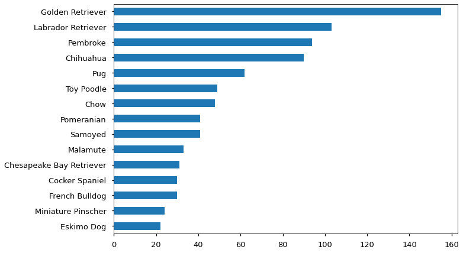

```python
df_final['breed'].value_counts()[:15][::-1].plot(kind='barh');
```

**As shown by the graph above, the Golden Retriever is the one chosen by most owners in the We Rate Dogs twitter account.**

## Q2: What are the sources of the tweets?

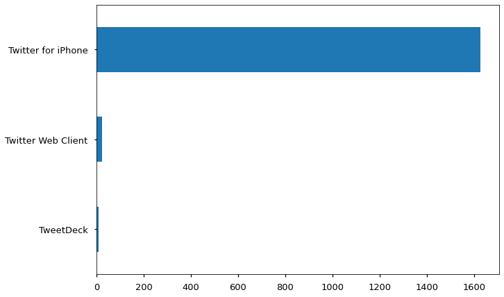

```python
df_final['source'].value_counts()[::-1].plot(kind='barh');
```

**By far "Twitter for iPhone" is the most used means of tweeting. I find this is strange because other platforms are underrepresented!**

## Q3: What are the top ratings given to dogs?

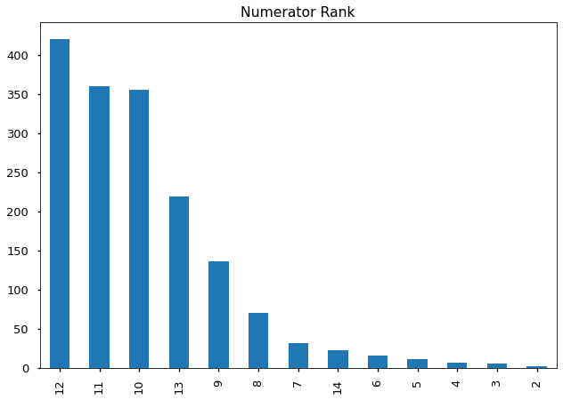

```python
df_final.numerator.astype('int').value_counts().plot(kind='bar', title='Numerator Rank');
```

**The majority of dogs are given a rating of between 10 and 12 out of 10.**

## Q4: How are the ratings ratio distributed?

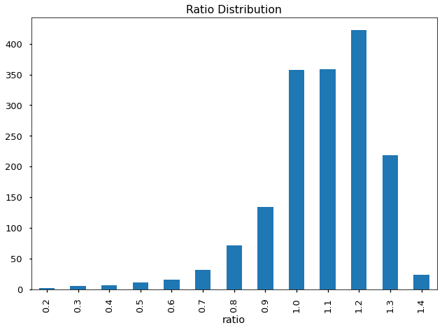

```python
df_final.groupby('ratio')['tweet_id'].count().plot(kind='bar', title='Ratio Distribution');
```

**The rating ratio is nicely distributed on a left-skewed distribution. We can see that fewer dogs get higher ratios and lower ratios. However, most ratios are between 1.0 and 1.3.**

## Q5: What are the top 10 names given to dogs?

```
Total names in dataset        = 1202
Total unique names in dataset = 850
```

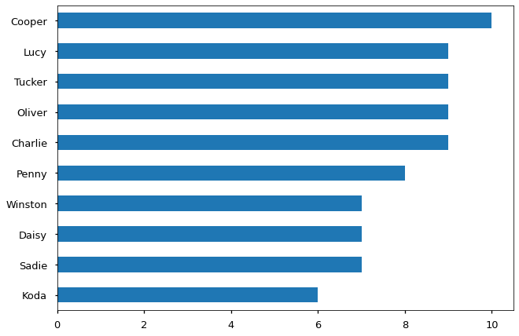

```python
print('Total names in dataset        =', df_final.name.count())
print('Total unique names in dataset =', df_final.name.nunique())
df_final.name.value_counts()[:10][::-1].plot(kind='barh');
```

**Although there are 1202 dog names available in the dataset, more than 70% of them are unique. The top name is Cooper.**

## Q6: What observations can you make from tweets character length?

```
----------------------------------------
The  mean  of "tweet_length" = 112.0
The median of "tweet_length" = 116.0
The  mode  of "tweet_length" = 141
----------------------------------------
```

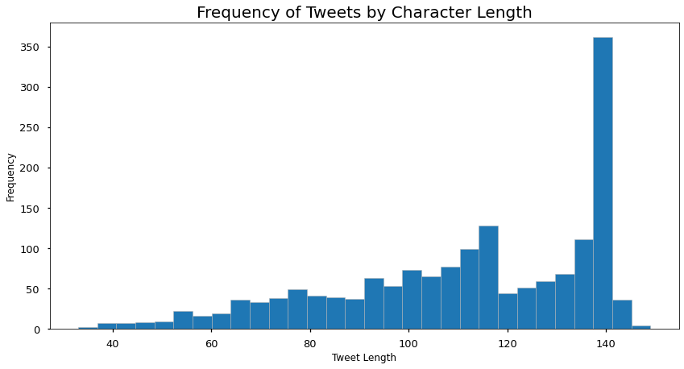

```python
print('-'*40)
print('The  mean  of "tweet_length" =', round(df_final['tweet_length'].mean(),0))
print('The median of "tweet_length" =', round(df_final['tweet_length'].median(),0))
print('The  mode  of "tweet_length" =', round(df_final['tweet_length'].mode()[0],0))
print('-'*40)

plt.subplots(figsize=(14, 7))
plt.title('Frequency of Tweets by Character Length', fontsize=20)
plt.xlabel('Tweet Length', fontsize=12)
plt.ylabel('Frequency', fontsize=12)
plt.hist(df_final.tweet_length, bins=30, histtype='bar', edgecolor='.7', linewidth=.5);
```

**The mean character length of tweets in the dataset is 112 characters, while the median is 116. However, the mode represents the maximum characters allowed by Twitter at the time.**

**The graph below is the frequency of Tweets by character length (1 to 140 characters) from the 500 million Tweet samples used by Scott Golder and Vladimir Barash (sample extracted from Twitter in late 2009) in their academic papers*.**

*Source: Abductive Intelligence https://tmblr.co/ZrDhKyEYN7K6

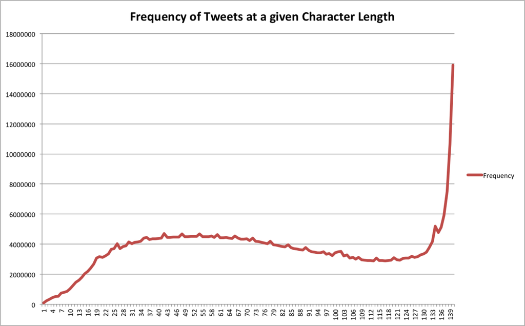

```python
Image('https://64.media.tumblr.com/tumblr_lxkivj9HAz1qbgrcmo1_r1_1280.png')
```

## Q7: How does dog stage rank when considered against the means and counts of retweets and likes?

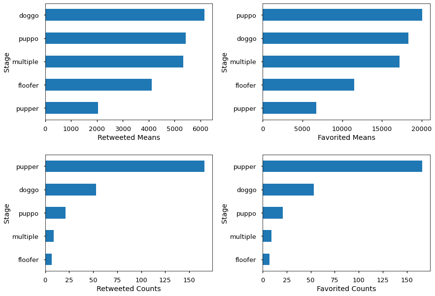

```python
plt.subplots(figsize=(14, 10))
plt.subplots_adjust(wspace = 0.3, hspace = 0.3)
plt.subplot(2, 2, 1)
df_final.groupby('stage').retweet_count.mean().sort_values().plot(kind='barh')
plt.xlabel('Retweeted Means')
plt.ylabel('Stage')
plt.subplot(2, 2, 2)
df_final.groupby('stage').favorite_count.mean().sort_values().plot(kind='barh')
plt.xlabel('Favorited Means')
plt.ylabel('Stage')
plt.subplot(2, 2, 3)
df_final.groupby('stage').retweet_count.count().sort_values().plot(kind='barh')
plt.xlabel('Retweeted Counts')
plt.ylabel('Stage')
plt.subplot(2, 2, 4)
df_final.groupby('stage').favorite_count.count().sort_values().plot(kind='barh')
plt.xlabel('Favorited Counts')
plt.ylabel('Stage');
```

**When considering means of retweets we find doggo is the top stage followed by puppo stage. But when we look at means of likes the ranking is reversed where puppo is the top stage followed by doggo stage. This is followed by the rest of the stages at the same ranking.**

**However, when we consider the counts of retweets and likes, the top rank goes to the pupper stage by a wide margin, more than the other stages combined!**

## Q8: How does dog rating ratio rank when considered against the means and counts of retweets and likes?

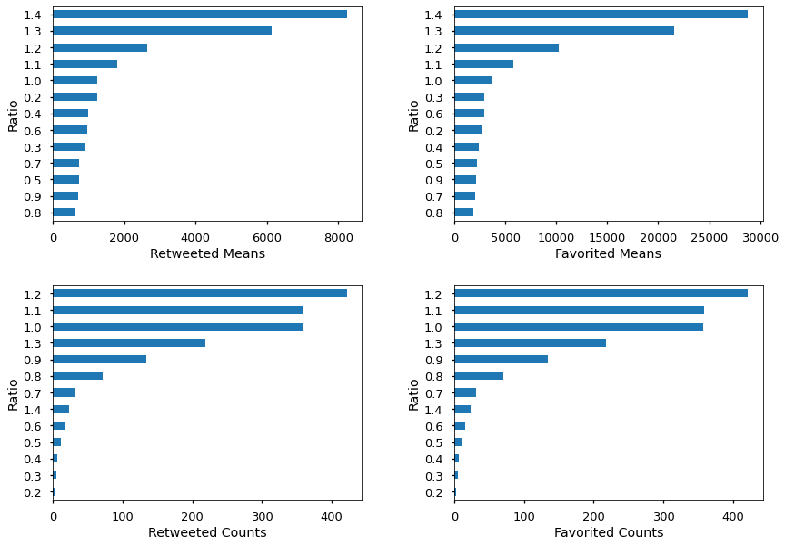

```python
plt.subplots(figsize=(14, 10))
plt.subplots_adjust(wspace = 0.3, hspace = 0.3)
plt.subplot(2, 2, 1)
df_final.groupby('ratio').retweet_count.mean().sort_values().plot(kind='barh')
plt.xlabel('Retweeted Means')
plt.ylabel('Ratio')
plt.subplot(2, 2, 2)
df_final.groupby('ratio').favorite_count.mean().sort_values().plot(kind='barh')
plt.xlabel('Favorited Means')
plt.ylabel('Ratio')
plt.subplot(2, 2, 3)
df_final.groupby('ratio').retweet_count.count().sort_values().plot(kind='barh')
plt.xlabel('Retweeted Counts')
plt.ylabel('Ratio')
plt.subplot(2, 2, 4)
df_final.groupby('ratio').favorite_count.count().sort_values().plot(kind='barh')
plt.xlabel('Favorited Counts')
plt.ylabel('Ratio');
```

**When considering means of retweets and likes the rating ratio of 1.4 is the top ranked, followed by 1.0 to 1.3 descending. However, when considering counts of retweets and likes the rating ratio, we find 1.2 to 1.0 are top ranked.**

## Q9: How does the monthly tweet count look across the time line of the dataset?

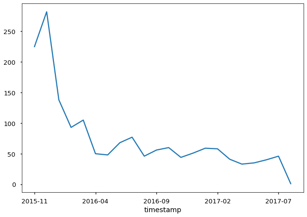

```python
df_final.groupby(df_final.timestamp.apply(lambda x:x.strftime('%Y-%m')))['tweet_id'].count().plot(kind='line');
```

**It seems like the We Rate Dogs account started with a storm of tweets in its beginning (Nov '15 - Jan '16). However, this was followed by decline and stabilization of the number of tweets per month.**

## Q10: How does the monthly favorite and retweet means look across the time line of the dataset?

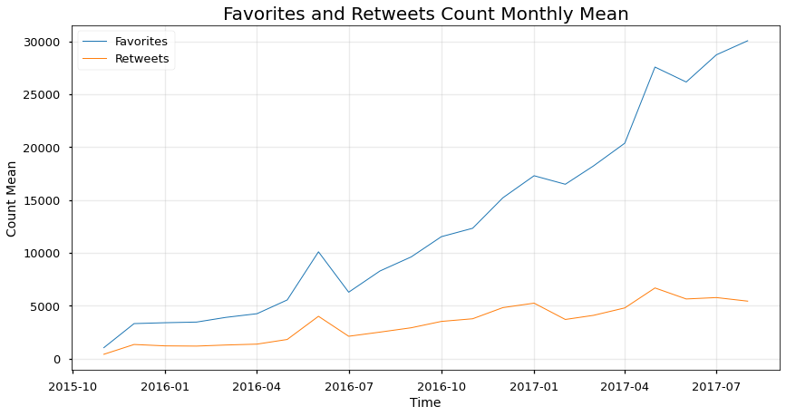

```python
# data = df_final.timestamp.apply(lambda x:x.strftime('%Y-%m'))
# fig, (ax1, ax2) = plt.subplots(2, sharex=True, figsize=(15,10))
# ax1.set_title('Favorite Count Monthly Mean')
# ax2.set_title('Retweet Count Monthly Mean')
# df_final.groupby(data)['favorite_count'].mean().plot(ax=ax1, kind='line', lw=1);
# df_final.groupby(data)['retweet_count'].mean().plot(ax=ax2, kind='line', lw=1);

timestamp_means = df_final[['timestamp', 'favorite_count', 'retweet_count']]
timestamp_means = timestamp_means.set_index('timestamp')
# timestamp_year = timestamp_means.resample('A').mean()
# timestamp_quarter = timestamp_means.resample('Q').mean()
timestamp_month = timestamp_means.resample('MS').mean()
# timestamp_week = timestamp_means.resample('W').mean()
# timestamp_day = timestamp_means.resample('D').mean()

fig, ax = plt.subplots(figsize=(14, 7))
plt.plot(timestamp_month.index, timestamp_month.favorite_count, lw=1, label='Favorites')
plt.plot(timestamp_month.index, timestamp_month.retweet_count, lw=1, label='Retweets')
plt.title('Favorites and Retweets Count Monthly Mean', fontsize=20)
plt.xlabel('Time', fontsize=14)
plt.ylabel('Count Mean', fontsize=14)
plt.legend()
plt.grid(True, alpha=0.25)
```

**It looks like the audience of We Rate Dogs account expanded over the time line of the dataset. The favorite and retweet count monthly mean increased in a linear fashion over time, while enjoying some viral moments (like Jun '16). Obviously, favorites far exceeded retweets.**

## Q11: What are the most represented years, months, and days across the time line of the dataset?

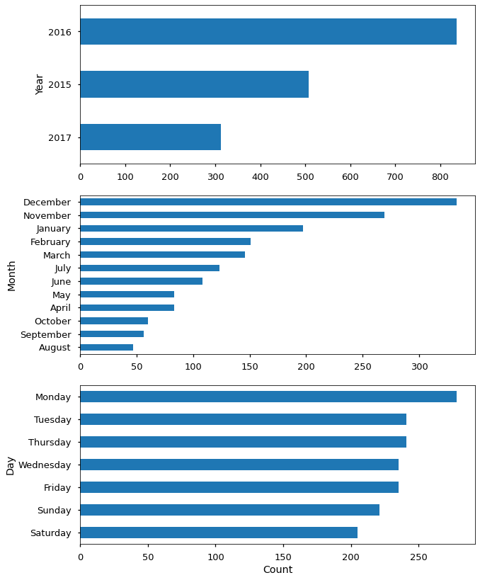

```python
fig, ax = plt.subplots(figsize=(10, 14))
plt.subplot(3, 1, 1)
df_final.groupby(df_final.timestamp.apply(lambda x:x.year))['tweet_id'].count().sort_values().plot(kind='barh')
plt.ylabel('Year')
plt.subplot(3, 1, 2)
df_final.groupby(df_final.timestamp.apply(lambda x:x.month_name()))['tweet_id'].count().sort_values().plot(kind='barh')
plt.ylabel('Month')
plt.subplot(3, 1, 3)
df_final.groupby(df_final.timestamp.apply(lambda x:x.day_name()))['tweet_id'].count().sort_values().plot(kind='barh')
plt.ylabel('Day')
plt.xlabel('Count');
```

**The most represented year is 2016, this is probably because it is the only full year in the dataset. Followed by 2015, which as shown before was the start of the account and the initial tweetstorm.**

**The most represented months are December and November for reasons similar to the above as they occurred twice in the time line, once during the initial tweetstorm. August, on the other hand, is the least represented month because although it occurred twice, one was during a decline.**

**The most represented day is Monday, and the least represented is the weekend. It only makes sense that the owner of the account wanted to enjoy their weekend and save the heavy work to Monday.**

## Q12: What is the relationship between retweets vs favorites counts?

```python
print('The correlation between retweets vs favorites counts =', df_final.retweet_count.corr(df_final.favorite_count))
```

```
The correlation between retweets vs favorites counts = 0.9306415298205322
```

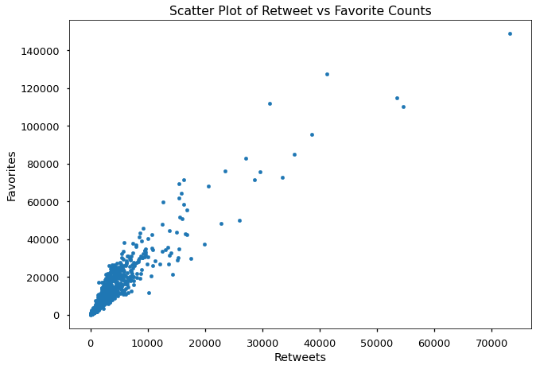

```python
df_final.plot('retweet_count', 'favorite_count', kind='scatter')
plt.title('Scatter Plot of Retweet vs Favorite Counts')
plt.xlabel('Retweets')
plt.ylabel('Favorites');
```

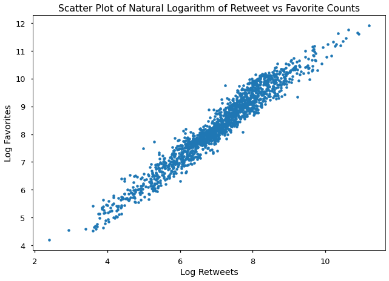

```python
plt.plot(pd.np.log(df_final.retweet_count), pd.np.log(df_final.favorite_count),'.')
plt.title('Scatter Plot of Natural Logarithm of Retweet vs Favorite Counts')
plt.xlabel('Log Retweets')
plt.ylabel('Log Favorites');
```

**The correlation between retweets vs favorites counts is very highly positive at 0.93, this is shown in the first graph also.**

**The second graph shows the same variables but in log scale, a more visual proof of a very highly positive relationship.**

## Q13: What are the most and least liked tweets in the dataset?

```
Here's a doggo realizing you can stand in a pool. 13/10 enlightened af (vid by Tina Conrad) https://t.co/7wE9LTEXC4
```

```python
print(list(df_final.loc[[df_final.favorite_count.idxmax()]]['text'])[0])
Image(list(df_final.loc[[df_final.favorite_count.idxmax()]]['jpg_url'])[0])
```

[output not shown]

```
Oh my. Here you are seeing an Adobe Setter giving birth to twins!!! The world is an amazing place. 11/10 https://t.co/11LvqN4WLq
```

```python
print(list(df_final.loc[[df_final.favorite_count.idxmin()]]['text'])[0])
Image(list(df_final.loc[[df_final.favorite_count.idxmin()]]['jpg_url'])[0])
```

[output not shown]